# Deputies Elections: votes Predictions

Jose Manoel Ferreira

November 07, 2018

## Introduction

This work is about to predict elections results based on previous data. So we’ll build predictive models and the variable target is **votos**.****

P.S.: Elections for brazilam Deputies department (Câmera Federal de Deputados)

Setting up a workspace

```r
setwd("~/git/data-analysis/lab02/part02/")
```

Building our dataframes

> > We have a data for test which we’ll will test our model and other data dedicated to train that model.

```r
test <- read.csv(("data/test.csv"))
train <- read.csv(("data/train.csv"))
```

The needed libraries.

```r
library(caret)
library(dplyr)
library(lars)
library(ggplot2)
```

We choosed to remove those three categoric variables in order to run the model, otherwise it would take too much time. But for a better result you could let them on the data.

```r
train <- train %>%
  select(-cargo, -nome, -ocupacao)
test <- test %>%
  select(-cargo, -nome, -ocupacao)
```

In the data would be better replace the NA for the column media, but we choosed replace by zero.

```r
train[is.na(train)] <- 0
test[is.na(test)] <- 0
```

# K-fold cross-validation

In order to tune our model we’ve used Cross-validation, basically it means search to the best values to improve our tests. There is some ways to use corss-validation which some are holdout, k-fold e leave-one-out

fitControl >> Control the computational nuances of the train function.

train >> This function sets up a grid of tuning parameters for a number of classification and regression routines, fits each model and calculates a resampling based performance measure.

Refereces from Carret Documentation.

```r
fitControl <- trainControl(## 10-fold CV
                           method = "repeatedcv", # boot", "boot632", "cv", "repeatedcv", "LOOCV", "LGOCV"
                           number = 10,
                           ## repeated ten times
                           repeats = 10)
```

A string vector that defines a pre-processing of the predictor data.

```r
preProcess = c("center", "scale","nzv" )
```

# Lasso Model

It’s a method that analyse regression, execute a selection and variable regularization to increase the prediction precision, also is able to select variable to zero if necessary.

```r
model.lasso <- train(votos ~ .,
               data = train,
               method = "lasso",
               metric = "RMSE",
               preProcess = preProcess,
               trControl = fitControl,
               na.action = na.exclude,
               tuneLength = 15)

model.lasso
```

```
## The lasso
##
## 7476 samples
##   20 predictors
##
## Pre-processing: centered (33), scaled (33), remove (49)
## Resampling: Cross-Validated (10 fold, repeated 10 times)
## Summary of sample sizes: 6728, 6730, 6728, 6729, 6728, 6728, ...
## Resampling results across tuning parameters:
##
##   fraction   RMSE      Rsquared   MAE
##   0.1000000  39123.72  0.3999627  16494.73
##   0.1571429  40792.00  0.3942884  16519.24
##   0.2142857  42613.61  0.3908954  16562.12
##   0.2714286  44499.78  0.3889552  16618.67
##   0.3285714  46416.90  0.3877497  16682.68
##   0.3857143  48353.97  0.3869298  16751.00
##   0.4428571  50303.69  0.3863691  16820.28
##   0.5000000  52262.99  0.3859572  16890.38
##   0.5571429  54227.03  0.3856640  16962.26
##   0.6142857  56196.71  0.3854031  17034.88
##   0.6714286  58170.76  0.3851762  17107.73
##   0.7285714  60146.47  0.3849968  17180.74
##   0.7857143  62124.31  0.3848424  17253.79
##   0.8428571  64103.78  0.3847104  17326.80
##   0.9000000  66083.66  0.3846138  17399.67
##
## RMSE was used to select the optimal model using the smallest value.
## The final value used for the model was fraction = 0.1.
```

The prediction for the trained model, which **votos** is our target variable.

```r
lasso_prediction <- predict(model.lasso,train)

lasso_data <- data.frame(pred = lasso_prediction, obs = train$votos)

lasso_cv<- round(defaultSummary(lasso_data),digits = 4)

lasso_cv
```

```
##       RMSE   Rsquared        MAE
## 36065.6835     0.4288 15960.5230
```

As suggested for the regression modelsm the parameter to be tuned is the lambda

```r
lambda.grid <- expand.grid(lambda = seq(0, 2, by=0.1))
```

# Ridge Model

Is a method of regularization which the mean objective is soften the atribuites which has some interferences, so avoiding the overffiting.

```r
model.ridge <- train(votos ~ .,
               data = train,
               method = "ridge",
               tuneGrid = lambda.grid,
               metric = "RMSE",
               trControl = fitControl,
               preProcess = preProcess)

model.ridge
```

```
## Ridge Regression
##
## 7476 samples
##   20 predictors
##
## Pre-processing: centered (33), scaled (33), remove (49)
## Resampling: Cross-Validated (10 fold, repeated 10 times)
## Summary of sample sizes: 6728, 6729, 6729, 6728, 6728, 6728, ...
## Resampling results across tuning parameters:
##
##   lambda  RMSE      Rsquared   MAE
##   0.0     50294.53  0.3875145  16817.17
##   0.1     37379.66  0.4197507  16136.17
##   0.2     37923.94  0.4172258  16064.80
##   0.3     38545.77  0.4151009  16080.28
##   0.4     39245.39  0.4132250  16180.17
##   0.5     40014.11  0.4115595  16345.86
##   0.6     40841.90  0.4100748  16563.16
##   0.7     41718.96  0.4087450  16828.65
##   0.8     42636.30  0.4075477  17128.33
##   0.9     43585.83  0.4064639  17458.28
##   1.0     44560.47  0.4054782  17817.80
##   1.1     45554.04  0.4045776  18204.16
##   1.2     46561.22  0.4037511  18613.54
##   1.3     47577.46  0.4029898  19039.78
##   1.4     48598.87  0.4022860  19478.99
##   1.5     49622.16  0.4016332  19927.83
##   1.6     50644.54  0.4010259  20385.43
##   1.7     51663.67  0.4004594  20850.97
##   1.8     52677.57  0.3999296  21322.25
##   1.9     53684.60  0.3994329  21795.77
##   2.0     54683.41  0.3989662  22271.33
##
## RMSE was used to select the optimal model using the smallest value.
## The final value used for the model was lambda = 0.1.
```

As result we’ve got a small lambda value meaning smal BIAS and HIGH variance.

```r
ridge_prediction <- predict(model.ridge,train)

ridge_data <- data.frame(pred = ridge_prediction, obs = train$votos)

ridge_cv <- round(defaultSummary(ridge_data),digits = 4)

ridge_cv
```

```
##       RMSE   Rsquared        MAE
## 36335.9584     0.4218 15886.5846
```

# KNN Model

k-nearest neighbour classification for test set from training set. For each row of the test set, the k nearest (in Euclidean distance) training set vectors are found, and the classification is decided by majority vote, with ties broken at random. If there are ties for the kth nearest vector, all candidates are included in the vote.

```r
model.knn <- train(votos ~ .,
               data = train,
               trControl = fitControl,
               method = "knn", # pode ser 'lasso'ldf
               metric = "RMSE",
               preProcess = preProcess)

model.knn
```

```
## k-Nearest Neighbors
##
## 7476 samples
##   20 predictors
##
## Pre-processing: centered (33), scaled (33), remove (49)
## Resampling: Cross-Validated (10 fold, repeated 10 times)
## Summary of sample sizes: 6729, 6729, 6729, 6728, 6728, 6728, ...
## Resampling results across tuning parameters:
##
##   k  RMSE      Rsquared   MAE
##   5  34697.94  0.4759877  13848.35
##   7  34600.99  0.4804227  13819.10
##   9  34512.29  0.4851613  13835.82
##
## RMSE was used to select the optimal model using the smallest value.
## The final value used for the model was k = 9.
```

```r
knn_prediction <- predict(model.knn,train)

knn_data <- data.frame(pred = knn_prediction, obs = train$votos)

knn_cv <- round(defaultSummary(knn_data),digits = 4)

knn_cv
```

```
##       RMSE   Rsquared        MAE
## 31454.9933     0.5855 12194.2161
```

# Models Comparison

Let’s see the performance for each model based on RMSE value.

#### RIDGE

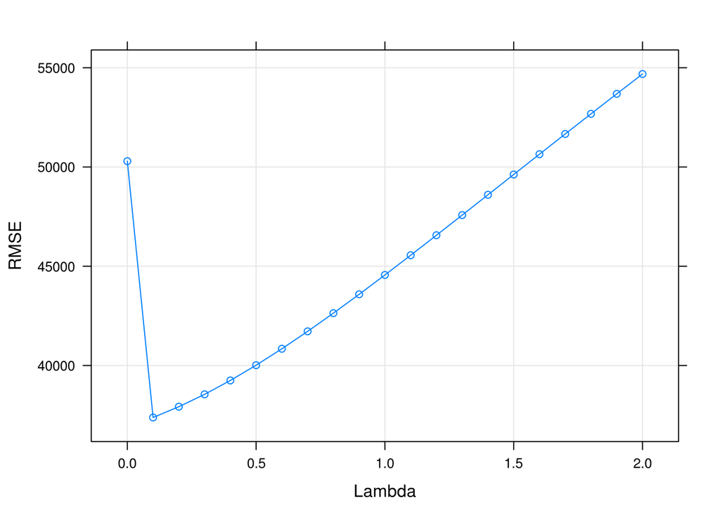

```r
plot(model.ridge, xlab = "Lambda", ylab = "RMSE")
```

#### LASSO

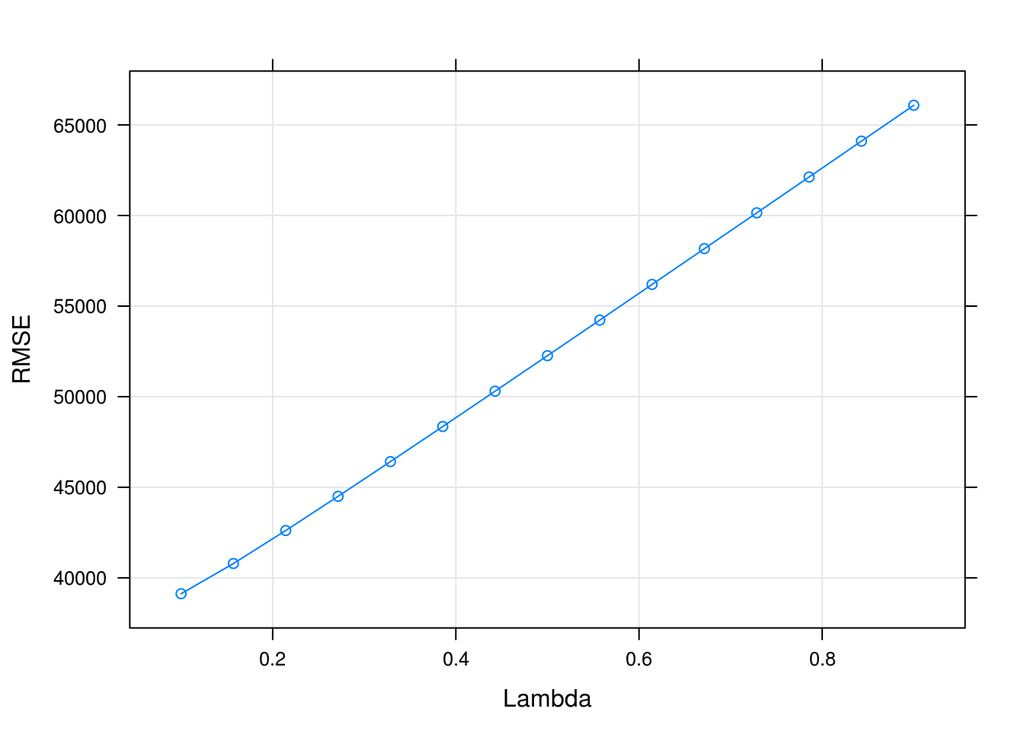

```r
plot(model.lasso, xlab = "Lambda", ylab = "RMSE")
```

#### KNN

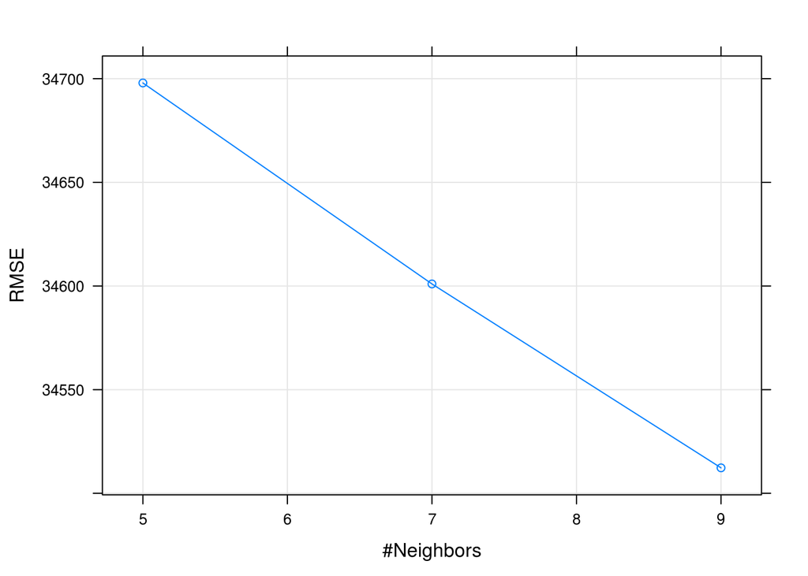

```r
plot(model.knn, ylab = "RMSE")
```

## Variables importances defined by the models

We’re going to see which variable are hilighted as importante for the models so the one not important either.

#### RIDGE

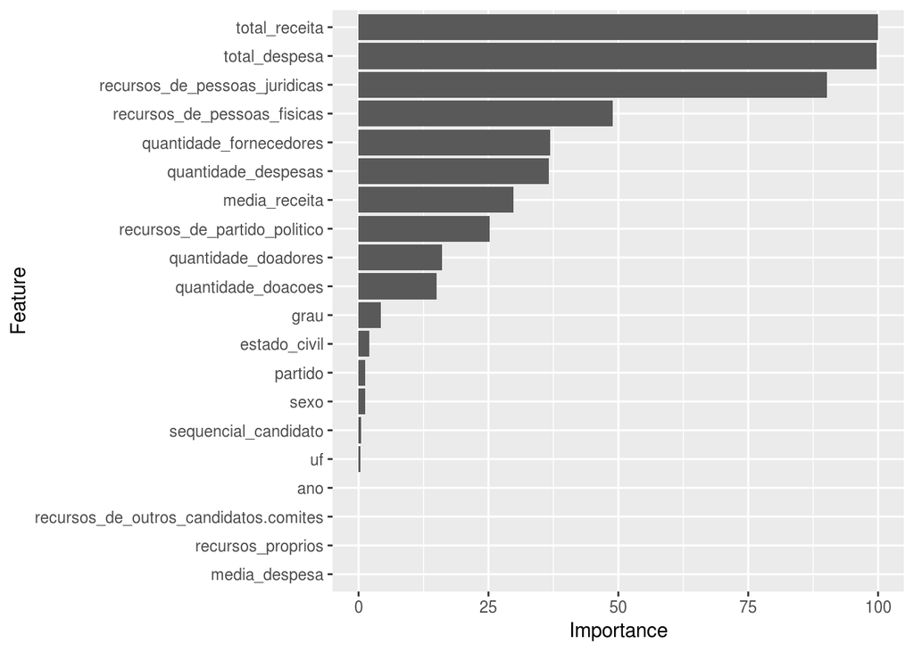

```r
ggplot(varImp(model.ridge))
```

#### LASSO

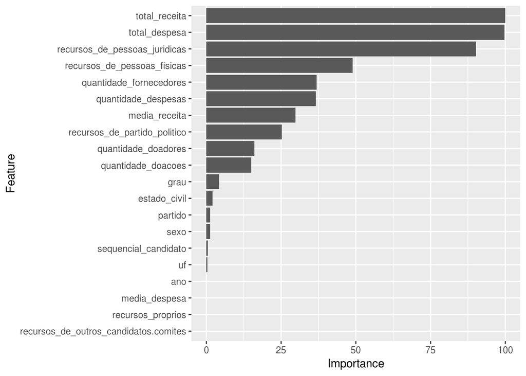

```r
ggplot(varImp(model.lasso))
```

#### KNN

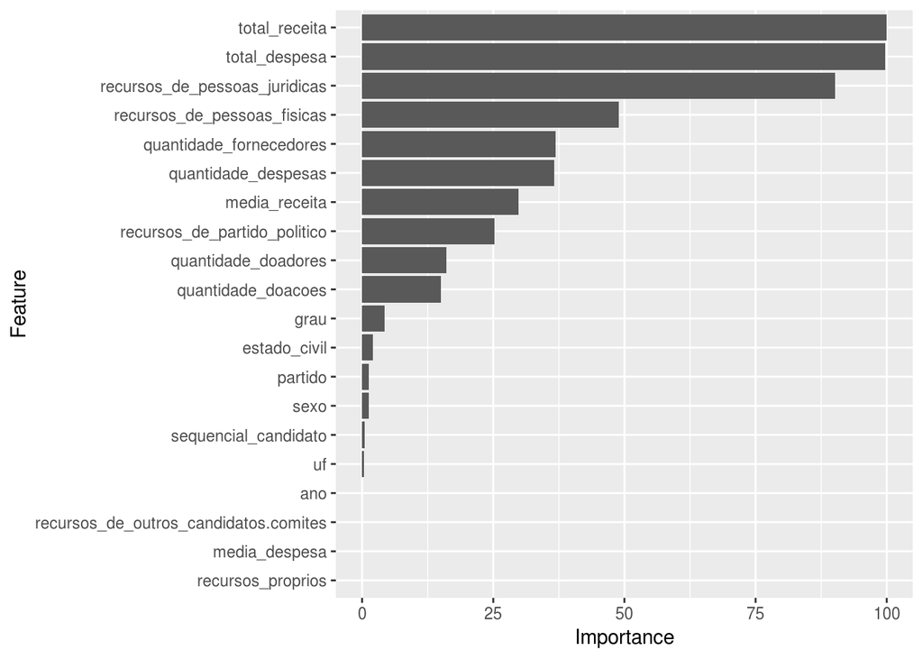

```r
ggplot(varImp(model.knn))
```

### RETRAIN

```r
newTrain <- train %>% select (-partido, -recursos_proprios,
                           -recursos_de_outros_candidatos.comites, -uf, -ano, -media_despesa)
newTest <- test %>% select (-partido, -recursos_proprios,
                           -recursos_de_outros_candidatos.comites, -uf, -ano, -media_despesa)
```

```r
grid <- expand.grid(k = model.knn$bestTune)
control <- trainControl(method = "optimism_boot")
newModel.KNN <- train(votos ~ .,
               data = newTrain,
               method = "knn",
               tuneGrid = grid,
               trControl = control,
               preProcess = preProcess,
               tuneLength= 50)
newModel.KNN
```

```
## k-Nearest Neighbors
##
## 7476 samples
##   14 predictors
##
## Pre-processing: centered (17), scaled (17), remove (5)
## Resampling: Bootstrapped (25 reps)
## Summary of sample sizes: 7476, 7476, 7476, 7476, 7476, 7476, ...
## Resampling results:
##
##   RMSE      Rsquared   MAE
##   35010.63  0.4891097  12189.27
##
## Tuning parameter 'k' was held constant at a value of 9
```

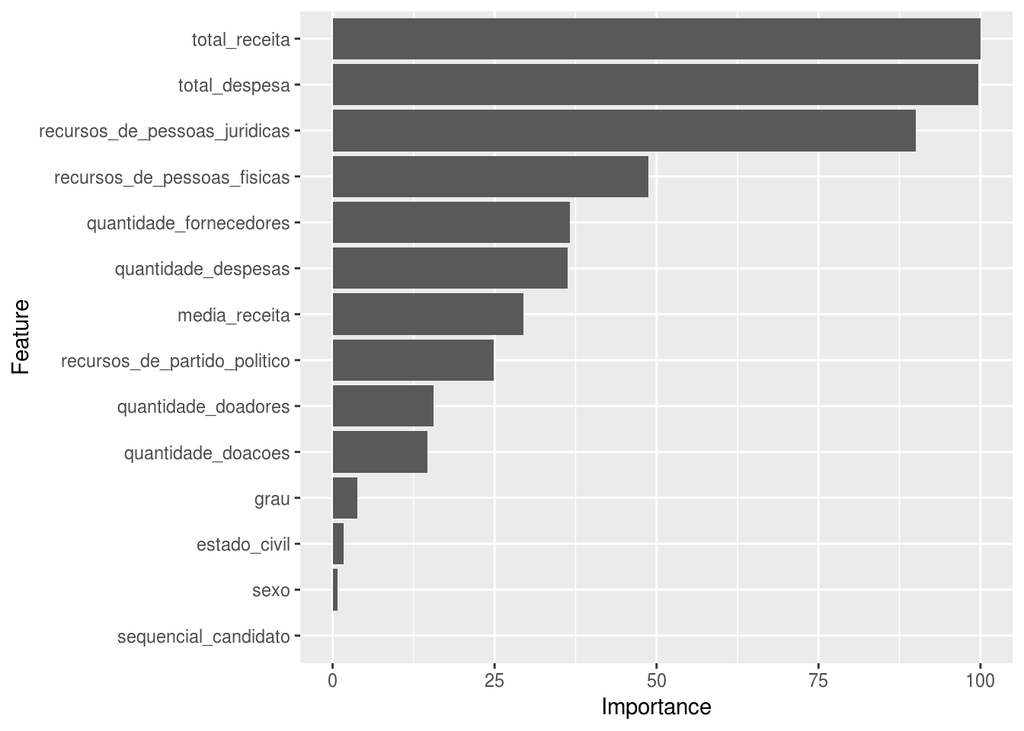

```r
ggplot(varImp(newModel.KNN))
```

### Kaggle challenge

As propose in the activite we are going to use our improved model to submite the votos prediction to the challenge in Kaggle.

```r
newKNN_prediction <- predict(newModel.KNN)
newKNN_data <- data.frame(pred = newKNN_prediction, obs = train$votos)
new_KNN_cv <- round(defaultSummary(newKNN_data), digits = 4)
new_KNN_cv
```

```
##      RMSE  Rsquared       MAE
## 30142.149     0.605 10891.306
```

```r
newModel.KNN $xlevels[["ocupacao"]] <- union(newModel.KNN$xlevels[["ocupacao"]], levels(newTest$ocupacao))
prediction_ <- predict(newModel.KNN , newTest)
ID <- newTest %>%
  select(sequencial_candidato)
colnames(ID)[colnames(ID)=="sequencial_candidato"] <- "ID"
predicted_file <- ID
predicted_file$votos <- prediction_
predicted_file$votos[predicted_file$votos < 0] <- 0
write.csv(predicted_file, "sample_submission.csv", row.names=FALSE)
```